# Merging BrainChart and ENIGMA outputs

## Load Libraries

```r
library(tidyverse)
```

```r
library(dplyr)
library(ggplot2)
```

## Load data

```r
# Load csv with brain age gap calculated using ENIGMA age prediction output
enigma_new <- read_csv("/external/rprshnas01/tigrlab/scratch/csun/brainage_proj/data/processed/enigma_new.csv")
```

```r
# Note the version of total disorder groupings used in enigma_new (0-2, 3-4, 5+)

# Load csv with centile scores from BrainChart
centiles_final <- read_csv("/KIMEL/tigrlab/scratch/csun/BrainChart_data/data/processed/centiles_final.csv")
# Note the version of total disorder groupings used in centiles_final (0-2, 3-4, 5+)

# Load csv with enigma csv with ASD diagnoses appended
enigma_ASD <- read_csv("/external/rprshnas01/tigrlab/scratch/csun/brainage_proj/data/processed/enigma_ASD.csv")
# load group_T1w.tsv
group_T1w <- read_delim("/external/rprshnas01/tigrlab/archive/data/TAY/pipelines/versioned_outputs/baseline_only/mriqc/group_T1w.tsv",
    delim = "\t", escape_double = FALSE,
    trim_ws = TRUE)
group_T1w
```

```
## # A tibble: 321 × 69
##    bids_name        cjv   cnr   efc  fber fwhm_avg fwhm_x fwhm_y fwhm_z icvs_csf
##    <chr>          <dbl> <dbl> <dbl> <dbl>    <dbl>  <dbl>  <dbl>  <dbl>    <dbl>
##  1 sub-CMH000000… 0.390  2.99 0.576  81       3.30   3.27   3.53   3.11    0.175
##  2 sub-CMH000000… 0.487  2.37 0.559  73.2     3.17   3.20   3.24   3.06    0.177
##  3 sub-CMH000000… 0.411  3.17 0.610  88.0     3.40   3.36   3.49   3.35    0.157
##  4 sub-CMH000000… 0.377  3.43 0.583  84.7     3.29   3.39   3.26   3.21    0.163
##  5 sub-CMH000000… 0.392  2.93 0.562  78.8     3.19   3.11   3.34   3.13    0.182
##  6 sub-CMH000000… 0.443  2.92 0.549 135.      3.45   3.44   3.58   3.34    0.147
##  7 sub-CMH000000… 0.400  3.07 0.573  82.5     3.30   3.31   3.40   3.19    0.191
##  8 sub-CMH000000… 0.478  2.33 0.566 114.      3.62   3.55   3.73   3.58    0.158
##  9 sub-CMH000000… 0.406  2.84 0.595  74.7     3.29   3.31   3.37   3.17    0.193
## 10 sub-CMH000000… 0.432  2.54 0.596  92.5     3.38   3.37   3.45   3.33    0.181
## # ℹ 311 more rows
## # ℹ 59 more variables: icvs_gm <dbl>, icvs_wm <dbl>, inu_med <dbl>,
## #   inu_range <dbl>, qi_1 <dbl>, qi_2 <dbl>, rpve_csf <dbl>, rpve_gm <dbl>,
## #   rpve_wm <dbl>, size_x <dbl>, size_y <dbl>, size_z <dbl>, snr_csf <dbl>,
## #   snr_gm <dbl>, snr_total <dbl>, snr_wm <dbl>, snrd_csf <dbl>, snrd_gm <dbl>,
## #   snrd_total <dbl>, snrd_wm <dbl>, spacing_x <dbl>, spacing_y <dbl>,
## #   spacing_z <dbl>, summary_bg_k <dbl>, summary_bg_mad <dbl>, …
```

```r
# load group_bold
group_bold <- read_delim("/external/rprshnas01/tigrlab/archive/data/TAY/pipelines/versioned_outputs/baseline_only/mriqc/group_bold.tsv",
    delim = "\t", escape_double = FALSE,
    trim_ws = TRUE)
group_bold
```

```
## # A tibble: 1,198 × 45
##    bids_name         aor     aqi dummy_trs dvars_nstd dvars_std dvars_vstd   efc
##    <chr>           <dbl>   <dbl>     <dbl>      <dbl>     <dbl>      <dbl> <dbl>
##  1 sub-CMH00000… 4.57e-4 0.00659         7       33.2      1.15      0.995 0.440
##  2 sub-CMH00000… 3.95e-4 0.00639         6       32.9      1.13      0.989 0.441
##  3 sub-CMH00000… 4.92e-4 0.00734        10       33.1      1.15      0.996 0.435
##  4 sub-CMH00000… 3.00e-4 0.00934         8       32.9      1.11      0.975 0.437
##  5 sub-CMH00000… 4.63e-4 0.00426        10       26.5      1.11      0.994 0.427
##  6 sub-CMH00000… 3.14e-4 0.00422        13       25.4      1.09      0.992 0.427
##  7 sub-CMH00000… 1.43e-3 0.00678        10       27.5      1.11      0.990 0.427
##  8 sub-CMH00000… 1.46e-3 0.00705         8       28.5      1.12      1.00  0.427
##  9 sub-CMH00000… 1.10e-2 0.00918         6       32.0      1.22      1.11  0.432
## 10 sub-CMH00000… 9.08e-3 0.0116          6       34.8      1.14      1.04  0.433
## # ℹ 1,188 more rows
## # ℹ 37 more variables: fber <dbl>, fd_mean <dbl>, fd_num <dbl>, fd_perc <dbl>,
## #   fwhm_avg <dbl>, fwhm_x <dbl>, fwhm_y <dbl>, fwhm_z <dbl>, gcor <dbl>,
## #   gsr_x <dbl>, gsr_y <dbl>, size_t <dbl>, size_x <dbl>, size_y <dbl>,
## #   size_z <dbl>, snr <dbl>, spacing_tr <dbl>, spacing_x <dbl>,
## #   spacing_y <dbl>, spacing_z <dbl>, summary_bg_k <dbl>, summary_bg_mad <dbl>,
## #   summary_bg_mean <dbl>, summary_bg_median <dbl>, summary_bg_n <dbl>, …
```

## Merge data frames

Create one data frame that includes BAG, centile scores, and ASD diagnoses

```r
# Append centile scores to enigma data frames
brainage_df <- merge(enigma_new,
                       centiles_final[c('participant', 'centile')], by ='participant', all.x = TRUE)
# merge by 'participant' column and append centile scores from centiles_final to enigma_new

# Append ASD diagnoses
brainage_merged <- merge(
  brainage_df,enigma_ASD[c('participant', 'ASD_dx')], by ='participant', all.x = TRUE)

# Reorder columns
brainage_merged <- select(brainage_merged, participant, sex, ASD_dx, dx, total_dx, total_dx_group, age_band, Age, age_prediction, BAG, centile)
brainage_merged
```

```
##         participant    sex ASD_dx      dx total_dx total_dx_group age_band
## 1   sub-CMH00000001 Female     No Non-PSS        5             5+    11-14
## 2   sub-CMH00000003 Female    Yes     PSS        5             5+    15-17
## 3   sub-CMH00000004   Male    Yes Non-PSS        2            0-2    15-17
## 4   sub-CMH00000005   Male    Yes Non-PSS        1            0-2    11-14
## 5   sub-CMH00000007 Female    Yes Non-PSS        2            0-2    15-17
## 6   sub-CMH00000008 Female    Yes Non-PSS        5             5+    15-17
## 7   sub-CMH00000009 Female    Yes     PSS        3            3-4    11-14
## 8   sub-CMH00000013 Female     No     PSS        2            0-2    15-17
## 9   sub-CMH00000016   Male     No     PSS        5             5+    15-17
## 10  sub-CMH00000017 Female   <NA> Non-PSS        4            3-4    18-21
## 11  sub-CMH00000019 Female     No Non-PSS        4            3-4    11-14
## 12  sub-CMH00000021   Male    Yes     PSS        2            0-2    15-17
## 13  sub-CMH00000023   Male     No Non-PSS        3            3-4    15-17
## 14  sub-CMH00000024   Male   <NA>     PSS        4            3-4      21+
```

[output cut: 585 more lines]

```r
# Create a "final" version of the merged data frame that excludes participants who are missing PSS/Non-PSS 'dx' info
brainage_final <- brainage_merged %>%
  filter(!is.na(dx)) # only keep rows that are not missing 'dx'
brainage_final
```

```
##         participant    sex ASD_dx      dx total_dx total_dx_group age_band
## 1   sub-CMH00000001 Female     No Non-PSS        5             5+    11-14
## 2   sub-CMH00000003 Female    Yes     PSS        5             5+    15-17
## 3   sub-CMH00000004   Male    Yes Non-PSS        2            0-2    15-17
## 4   sub-CMH00000005   Male    Yes Non-PSS        1            0-2    11-14
## 5   sub-CMH00000007 Female    Yes Non-PSS        2            0-2    15-17
## 6   sub-CMH00000008 Female    Yes Non-PSS        5             5+    15-17
## 7   sub-CMH00000009 Female    Yes     PSS        3            3-4    11-14
## 8   sub-CMH00000013 Female     No     PSS        2            0-2    15-17
## 9   sub-CMH00000016   Male     No     PSS        5             5+    15-17
## 10  sub-CMH00000017 Female   <NA> Non-PSS        4            3-4    18-21
## 11  sub-CMH00000019 Female     No Non-PSS        4            3-4    11-14
## 12  sub-CMH00000021   Male    Yes     PSS        2            0-2    15-17
## 13  sub-CMH00000023   Male     No Non-PSS        3            3-4    15-17
## 14  sub-CMH00000024   Male   <NA>     PSS        4            3-4      21+
```

[output cut: 561 more lines]

```r
# filter for NA for PSS and Non-PSS (~13)
```

```r
# females only
brainage_female <- filter(brainage_final, sex == "Female")
brainage_female
```

```
##         participant    sex ASD_dx      dx total_dx total_dx_group age_band
## 1   sub-CMH00000001 Female     No Non-PSS        5             5+    11-14
## 2   sub-CMH00000003 Female    Yes     PSS        5             5+    15-17
## 3   sub-CMH00000007 Female    Yes Non-PSS        2            0-2    15-17
## 4   sub-CMH00000008 Female    Yes Non-PSS        5             5+    15-17
## 5   sub-CMH00000009 Female    Yes     PSS        3            3-4    11-14
## 6   sub-CMH00000013 Female     No     PSS        2            0-2    15-17
## 7   sub-CMH00000017 Female   <NA> Non-PSS        4            3-4    18-21
## 8   sub-CMH00000019 Female     No Non-PSS        4            3-4    11-14
## 9   sub-CMH00000025 Female   <NA> Non-PSS        2            0-2    18-21
## 10  sub-CMH00000027 Female     No     PSS        1            0-2    15-17
## 11  sub-CMH00000028 Female   <NA>     PSS        5             5+    18-21
## 12  sub-CMH00000029 Female   <NA> Non-PSS        3            3-4      21+
## 13  sub-CMH00000030 Female   <NA>     PSS        5             5+      21+
## 14  sub-CMH00000035 Female   <NA>     PSS        6             5+      21+
```

[output cut: 387 more lines]

```r
# males only
brainage_male <- filter(brainage_final, sex == "Male")
brainage_male
```

```
##        participant  sex ASD_dx      dx total_dx total_dx_group age_band   Age
## 1  sub-CMH00000004 Male    Yes Non-PSS        2            0-2    15-17 15.12
## 2  sub-CMH00000005 Male    Yes Non-PSS        1            0-2    11-14 12.35
## 3  sub-CMH00000016 Male     No     PSS        5             5+    15-17 15.80
## 4  sub-CMH00000021 Male    Yes     PSS        2            0-2    15-17 17.77
## 5  sub-CMH00000023 Male     No Non-PSS        3            3-4    15-17 16.79
## 6  sub-CMH00000024 Male   <NA>     PSS        4            3-4      21+ 24.79
## 7  sub-CMH00000033 Male   <NA> Non-PSS        3            3-4      21+ 24.16
## 8  sub-CMH00000036 Male     No Non-PSS        3            3-4    15-17 17.88
## 9  sub-CMH00000039 Male     No Non-PSS        3            3-4    11-14 12.53
## 10 sub-CMH00000040 Male   <NA> Non-PSS        4            3-4      21+ 24.29
## 11 sub-CMH00000049 Male     No Non-PSS        1            0-2    11-14 12.99
## 12 sub-CMH00000050 Male    Yes     PSS        3            3-4    11-14 14.36
## 13 sub-CMH00000056 Male   <NA>     PSS        3            3-4      21+ 24.53
## 14 sub-CMH00000060 Male    Yes Non-PSS        3            3-4    18-21 18.09
```

[output cut: 161 more lines]

## Save new data frames as csv

```r
write.csv(brainage_final, "/KIMEL/tigrlab/scratch/csun/brainage_proj/data/processed/brainage_final.csv", row.names = FALSE)
```

## Data visualization

What are the demographic variables we are working with? 1) Age - scan age 2) sex - sex assigned at birth 3) dx - diagnosis for PSS or Non-PSS 4) ASD_dx - indicates if participant has been diagnosed with ASD based on KSADS (only applicable to participants < age 18) 5) age_band - derived grouping (11-14, 15-17, 18-21, 21+) 6) total_dx - numerical value representing the summed total number of disorders 7) total_dx_group - derived grouping (0-2, 3-4, 5+)

What are the computed variables we are working with? 1) age_prediction - brain age predicted by ENIGMA 2) BAG - brain age gap calculated as the difference between brain age and scan age (age_prediction - Age) 3) centile - centile score predicted by BrainChart *4) qi_1 - QA metrics (not added yet)

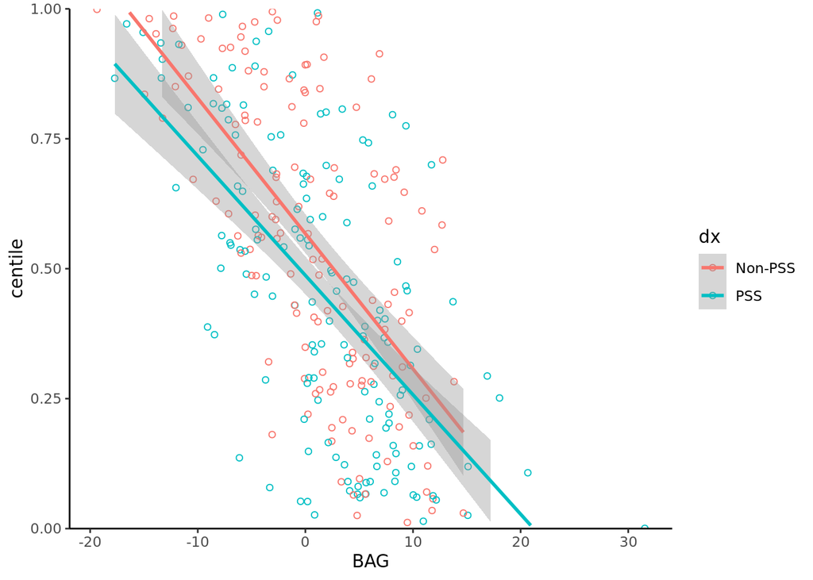

```r
# plot BAG vs centile scores grouped by PSS and Non-PSS
ggplot(data = brainage_final, aes(x = BAG, y = centile, colour = dx)) +
       geom_point(shape = 1) + # Use hollow circles
  geom_smooth(method=lm) +
  # Add linear regression line that includes 95% confidence region by default
  scale_y_continuous(limits = c(0,1), expand = c(0,0)) +
  # use scale_y_continuous to set the range of the y-axis
  theme_classic()
```

```r
# Source: http://www.cookbook-r.com/Graphs/Scatterplots_(ggplot2)/

cor.test(brainage_final$centile, brainage_final$BAG, method = "pearson")
```

```
##
##  Pearson's product-moment correlation
##
## data:  brainage_final$centile and brainage_final$BAG
## t = -13.857, df = 285, p-value < 2.2e-16
## alternative hypothesis: true correlation is not equal to 0
## 95 percent confidence interval:
##  -0.6988872 -0.5597829
## sample estimates:
##        cor
## -0.6344441
```

The scatter plot suggests a negative correlation between centile scores and brain age gap for both PSS and Non-PSS groups. However, the BAG range for PSS participants appears to broader (longer line).

Q: why is the average centile score lower for individuals with PSS? Q: why is the average BAG greater for individuals with ASD?

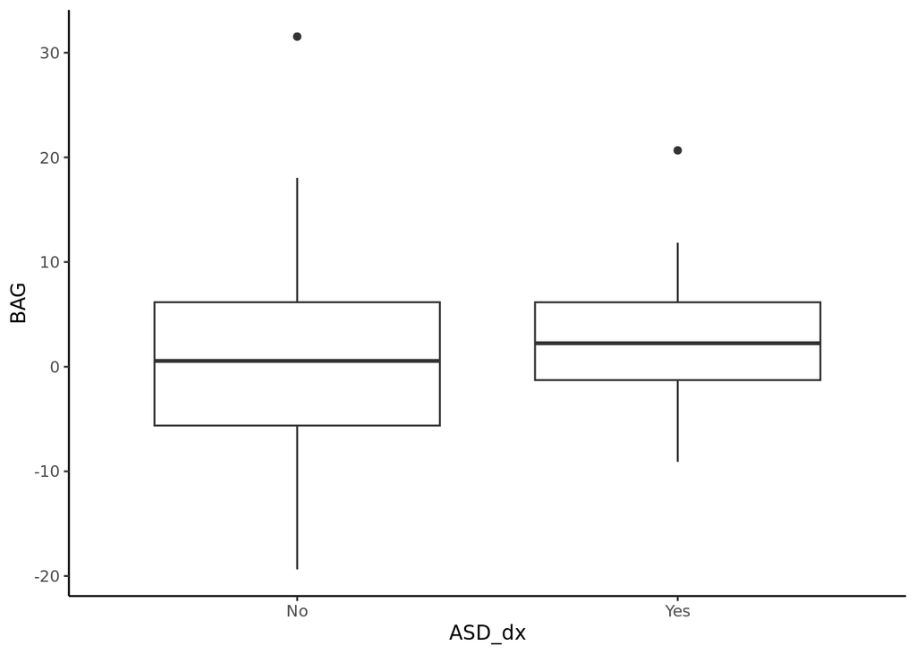

```r
# plot BAG among participants with and without ASD
ggplot(data = subset(brainage_final, !is.na(ASD_dx)), aes(x = ASD_dx, y = BAG)) +
       geom_boxplot() +
  theme_classic()
```

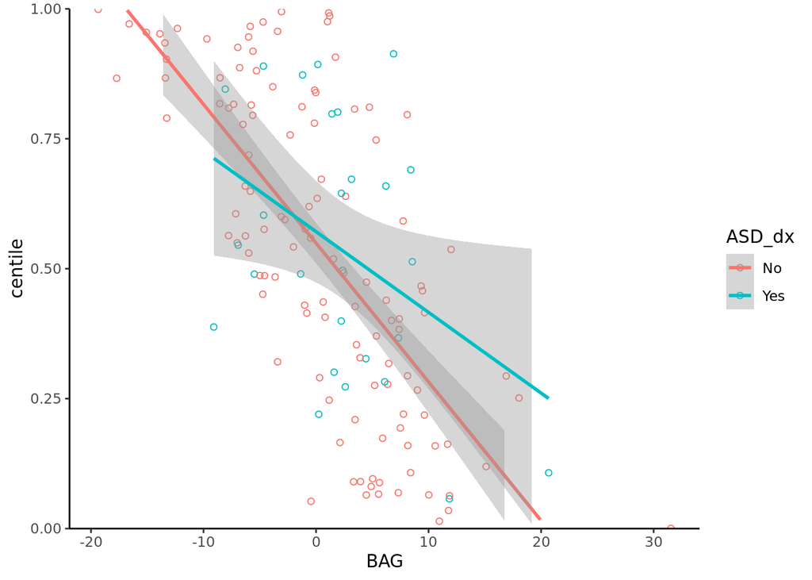

```r
# Compare BAG and centile scores between participants with and without ASD
ggplot(data = subset(brainage_final, !is.na(ASD_dx)), aes(x = BAG, y = centile, colour = ASD_dx)) +
       geom_point(shape = 1) + # Use hollow circles
  geom_smooth(method=lm) +
  # Add linear regression line that includes 95% confidence region by default
  scale_y_continuous(limits = c(0,1), expand = c(0,0)) +
  # use scale_y_continuous to set the range of the y-axis
  theme_classic()
```

```r
# look at PSS and ASD
```

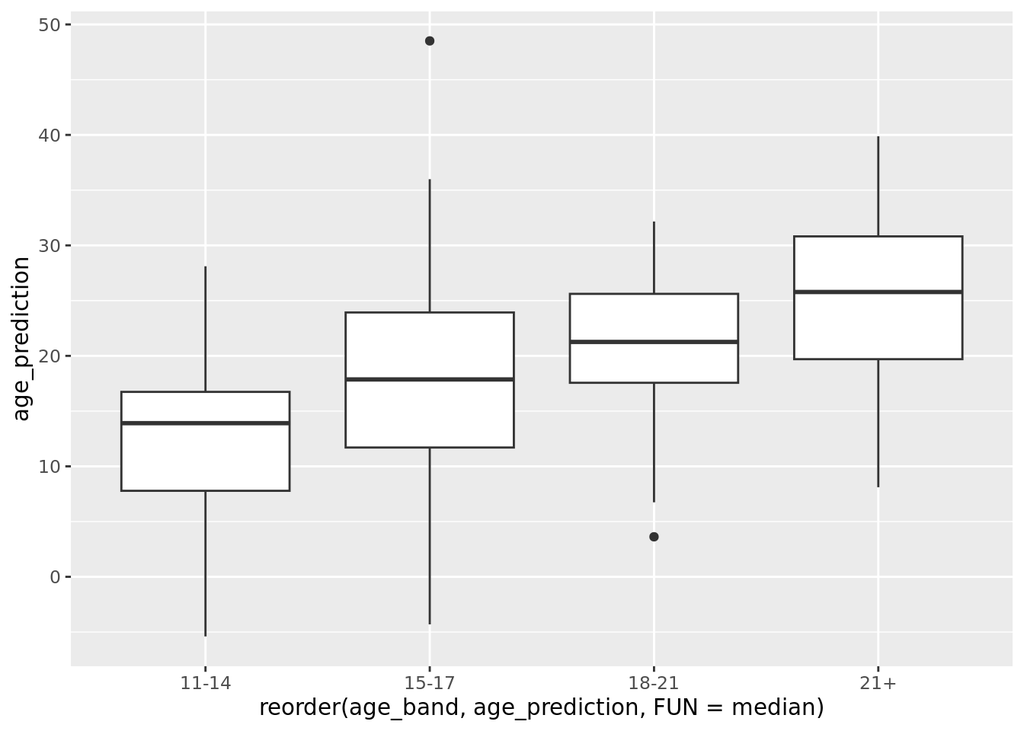

```r
# use the reorder() function within aes to reorder the x variable based on the median value of the y variable

# Age prediction
ggplot(data = brainage_final, aes(x = reorder(age_band, age_prediction, FUN = median), y = age_prediction)) +
  geom_boxplot()
```

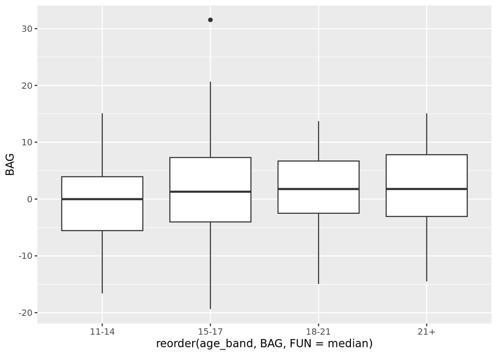

```r
# Brain age gap
ggplot(data = brainage_final, aes(x = reorder(age_band, BAG, FUN = median), y = BAG)) +
  geom_boxplot()
```

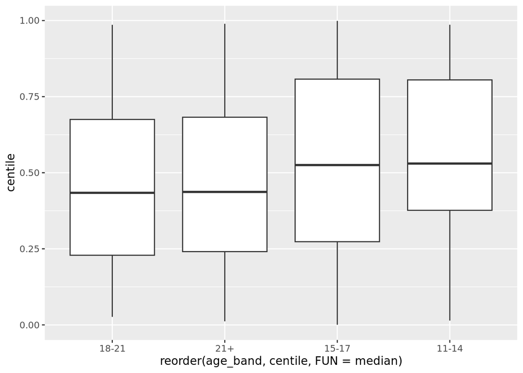

```r
# Centile scores
ggplot(data = brainage_final, aes(x = reorder(age_band, centile, FUN = median), y = centile)) +
  geom_boxplot()
```

The box plot shows that the 15-17 age band has the largest range of centile scores.

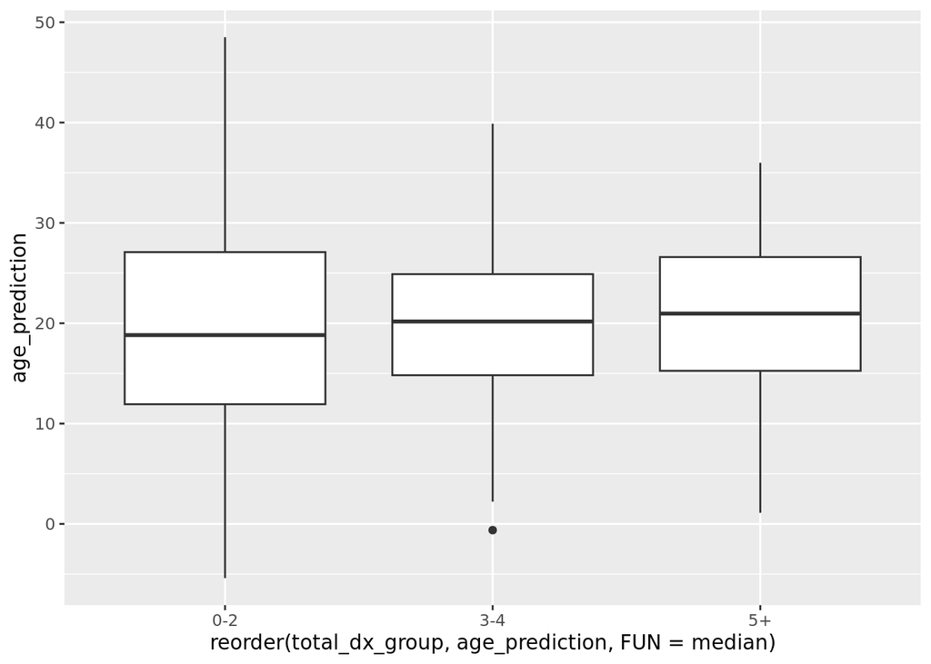

```r
# Age prediction
ggplot(data = brainage_final, aes(x = reorder(total_dx_group, age_prediction, FUN = median), y = age_prediction)) +
  geom_boxplot()
```

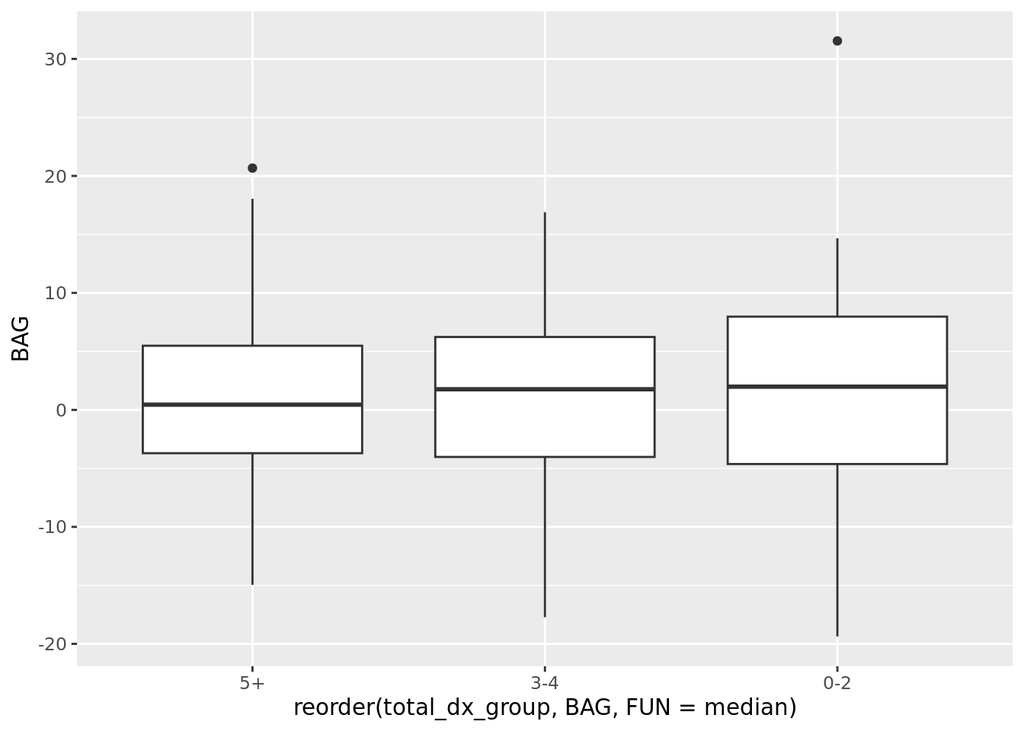

```r
# Brain age gap
ggplot(data = brainage_final, aes(x = reorder(total_dx_group, BAG, FUN = median), y = BAG)) +
  geom_boxplot()
```

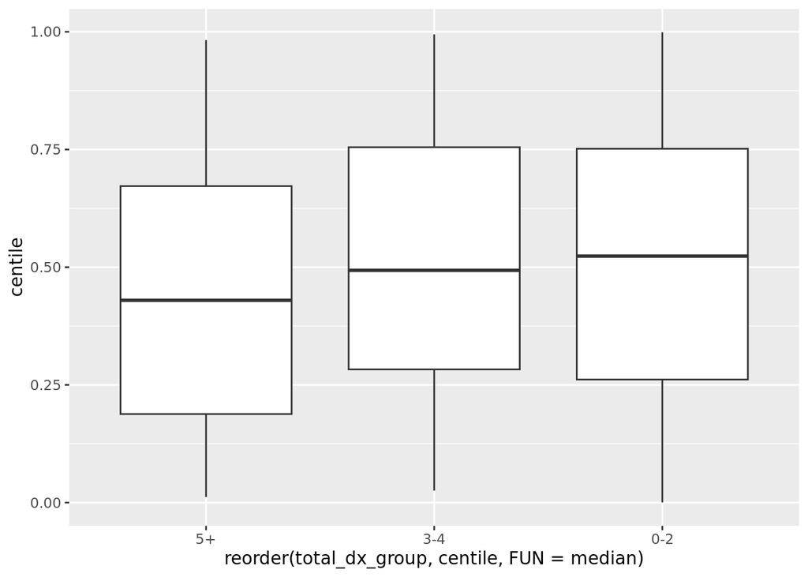

```r
# Centile score
ggplot(data = brainage_final, aes(x = reorder(total_dx_group, centile, FUN = median), y = centile)) +
  geom_boxplot()
```

## Linear models

```r
# relationship between
# figure out how to do the analysis by category - e.g., linear model for just the youngest age group or lm for the participants with 5+ total disorders
```